# INN Hotels Project

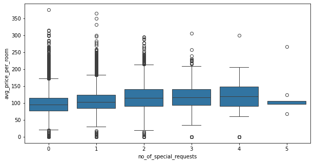

```python
## Code to create boxplot for no of special requests and average price per room (excluding the outliers)
plt.figure(figsize=(10, 5))
sns.boxplot(data=data,x='no_of_special_requests', y='avg_price_per_room')
plt.show()
```

Observations: The highest median average price per room for bookings that made special requests were observed by those who made 2-4 request followed by 1 and 5. Bookings that did not make any requests paid the least median average price per room as compared to those that made requests.

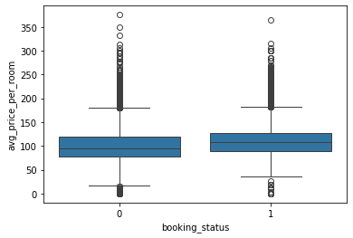

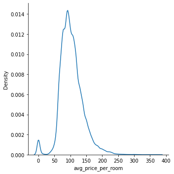

```python
# Box and distribution plot for booking status and average price per room
# (cancelled =1 and not cancelled=0)

sns.boxplot(data=data,x='booking_status',y='avg_price_per_room')
plt.show()
sns.displot(data=data,x='avg_price_per_room',kind='kde')
plt.show()
```

Observations: Bookings that were cancelled paid higher median average price per room compared to those that did not cancel. The distribution of average price per room was almost normal with a greater proportion of bookings paying about 100.

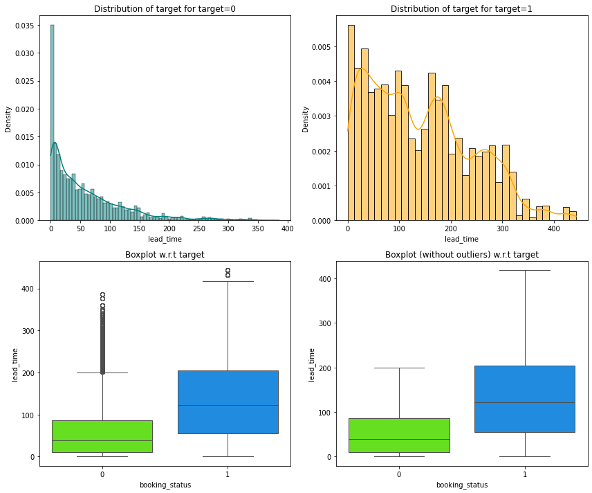

```python
## Code for distribution of lead time wrt booking status
distribution_plot_wrt_target(data, "lead_time", "booking_status")
```

Observations: There is a shorter lead time for not cancelled compared to cancelled. The lead time for cancelled is generally higher and the range is long compared to not cancelled.

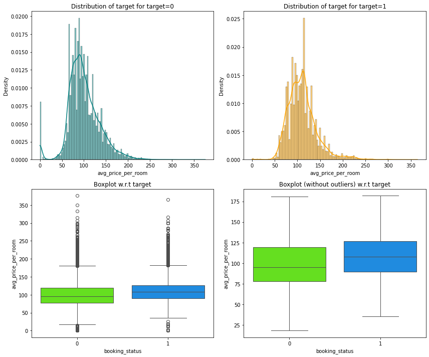

```python
# distribution plot of average price per room and booking status
distribution_plot_wrt_target(data, "avg_price_per_room", "booking_status")
```

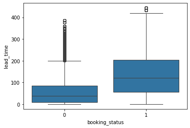

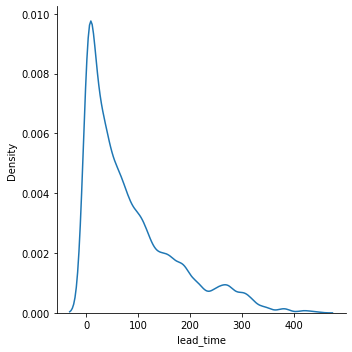

```python
#distribution_plot for lead time and boxplot for booking status vs lead time
# (cancelled =1 and not cancelled=0)
sns.boxplot(data=data,x='booking_status',y='lead_time')
plt.show()
sns.displot(data=data,x='lead_time',kind='kde')
plt.show()
```

Observations: The lead time for thise that cancelled was higher than those than did not cancel. The distribution of the lead time was skewed to the right.

Repeating guests are the guests who stay in the hotel often and are important to brand equity. Let's see what percentage of repeating guests cancel

```
booking_status      0      1    All
repeated_guest
All             24390  11885  36275
0               23476  11869  35345
1                 914     16    930
------------------------------------------------------------------------------------------------------------------------
```

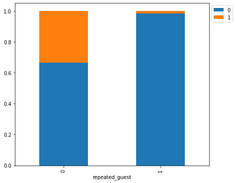

```python
## Code for stacked barplot for repeated guests and booking status
# (cancelled =1 and not cancelled=0)
stacked_barplot(data, "repeated_guest", "booking_status")
```

Observations: First time guests were more likely to cancel bookings compared to repeated guests were not likely to cancel bookings. So most bookings were cancelled by guests who were not repeat guests

#### Busiest month

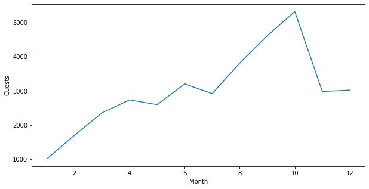

```python
# grouping the data on arrival months and extracting the count of bookings
monthly_data = data.groupby(["arrival_month"])["booking_status"].count()

# creating a dataframe with months and count of customers in each month
monthly_data = pd.DataFrame(
    {"Month": list(monthly_data.index), "Guests": list(monthly_data.values)}
)

# plotting the trend over different months
plt.figure(figsize=(10, 5))
sns.lineplot(data=monthly_data, x="Month", y="Guests")
plt.show()
```

Generally people travel with their spouse and children for vacations or other activities. Let's create a new dataframe of the customers who traveled with their families and analyze the impact on booking status.

```python
family_data = data[(data["no_of_children"] >= 0) + (data["no_of_adults"] > 1)]
family_data.shape
```

```
(36275, 18)
```

Observations: family data dataset has 18 columns and 36275 entries.

```python
import pandas as pd

# Assuming 'data' is your DataFrame containing 'no_of_children' and 'no_of_adults' columns
data["family_members"] = data["no_of_children"] + data["no_of_adults"]

# Selecting rows where the total number of family members is greater than 1
family_data = data[data["family_members"] > 1]
```

```python
family_data.shape
```

```
(28723, 19)
```

```
booking_status      0      1    All
family_members
All             18647  10076  28723
2               15662   8280  23942
3                2459   1392   3851
4                 514    398    912
5                  10      5     15
11                  0      1      1
10                  1      0      1
12                  1      0      1
------------------------------------------------------------------------------------------------------------------------
```

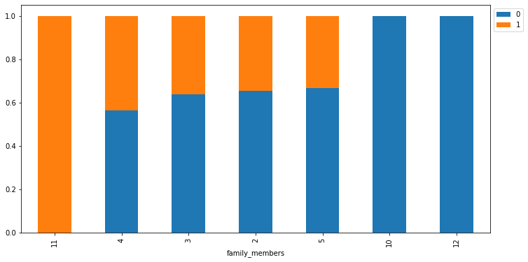

```python
## Code to plot stacked barplot for number of family members and booking status
# (cancelled =1 and not cancelled=0)
stacked_barplot(family_data, "family_members", "booking_status")
```

```python
stay_data = data[(data["no_of_week_nights"] > 0) & (data["no_of_weekend_nights"] > 0)]
stay_data.shape
```

```
(17094, 19)
```

Observations: New dataframe

```python
stay_data["total_days"] = (
    stay_data["no_of_week_nights"] + stay_data["no_of_weekend_nights"]
)
```

```python
import pandas as pd

# Assuming stay_data is a Pandas DataFrame
stay_data["total_days"] = (
    stay_data["no_of_week_nights"] + stay_data["no_of_weekend_nights"]
)

# Displaying the first few rows to verify the new column
print(stay_data.head())
```

```
   no_of_adults  no_of_children  no_of_weekend_nights  no_of_week_nights  \
0             2               0                     1                  2
1             2               0                     2                  3
2             1               0                     2                  1
4             2               0                     1                  1
6             2               0                     1                  3

  type_of_meal_plan  required_car_parking_space room_type_reserved  lead_time  \
0       Meal Plan 1                           0        Room_Type 1        224
1      Not Selected                           0        Room_Type 1          5
2       Meal Plan 1                           0        Room_Type 1          1
4      Not Selected                           0        Room_Type 1         48
6       Meal Plan 1                           0        Room_Type 1         34

   arrival_year  arrival_month  arrival_date market_segment_type  \
```

[output cut: 26 more lines]

New dataframe indicating a new colum called total days

```
booking_status      0     1    All
total_days
All             10979  6115  17094
3                3689  2183   5872
4                2977  1387   4364
5                1593   738   2331
2                1301   639   1940
6                 566   465   1031
7                 590   383    973
8                 100    79    179
10                 51    58    109
9                  58    53    111
14                  5    27     32
15                  5    26     31
13                  3    15     18
12                  9    15     24
11                 24    15     39
20                  3     8     11
19                  1     5      6
16                  1     5      6
17                  1     4      5
18                  0     3      3
21                  1     3      4
22                  0     2      2
23                  1     1      2
24                  0     1      1
------------------------------------------------------------------------------------------------------------------------
```

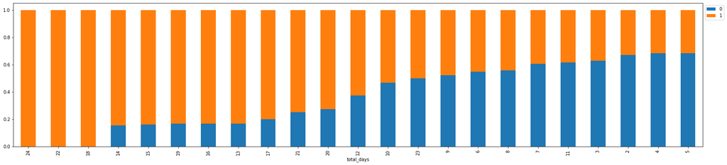

```python
# barplot of tatal daya and status
# (cancelled =1 and not cancelled=0)
stacked_barplot(stay_data,"total_days", "booking_status")
```

```
booking_status      0     1    All
arrival_month
All             10979  6115  17094
10               1539   913   2452
8                1068   822   1890
9                1203   792   1995
7                 862   751   1613
6                 706   541   1247
4                 906   482   1388
5                 779   474   1253
3                 807   436   1243
11                920   360   1280
2                 556   268    824
12               1237   263   1500
1                 396    13    409
------------------------------------------------------------------------------------------------------------------------
```

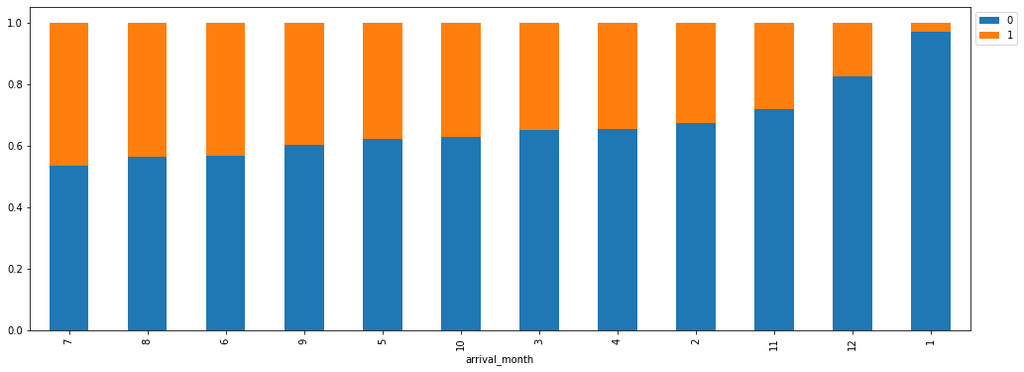

```python
# arrival month vs booking status
# (cancelled =1 and not cancelled=0)
stacked_barplot(stay_data,"arrival_month", "booking_status")
```

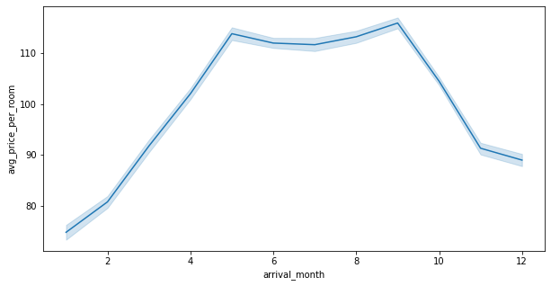

```python
## Code to create lineplot between average price per room and arrival month
plt.figure(figsize=(10, 5))
sns.lineplot(data=data, x='arrival_month', y='avg_price_per_room')
plt.show()
```

The average price per room differed across the arrival month. Thus the arrival month determined the room average room pprice. The room price was highest between month 5 and 9. After month 9 the prices decreased and staterted picking up from month 2 till 5 again.

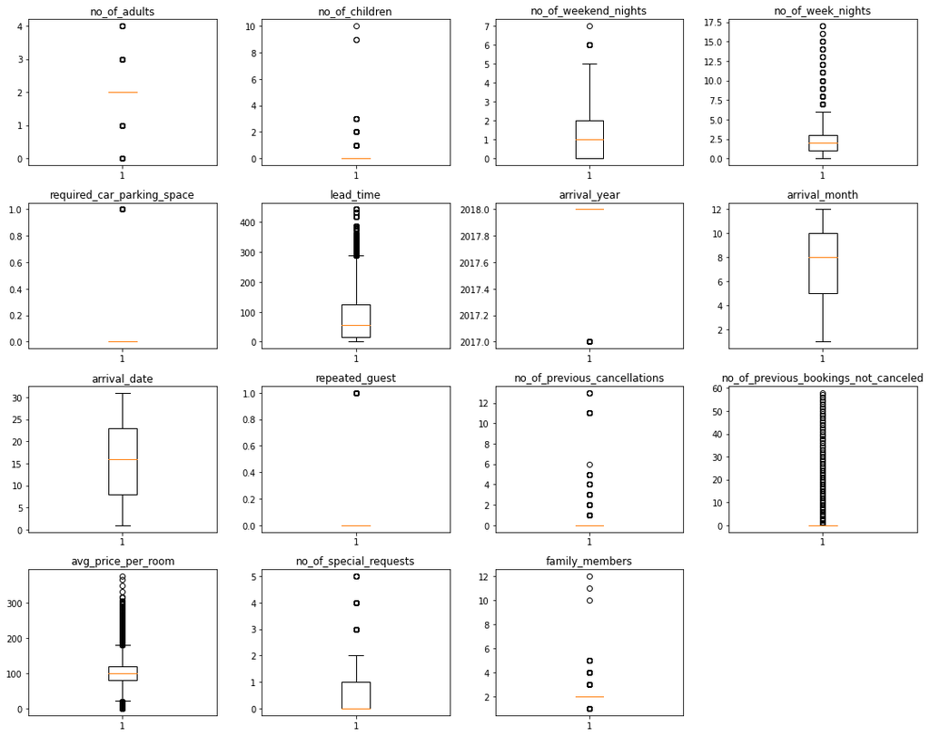

```python
# outlier detection using boxplot
numeric_columns = data.select_dtypes(include=np.number).columns.tolist()
# dropping release_year as it is a temporal variable
numeric_columns.remove("booking_status")

plt.figure(figsize=(15, 12))

for i, variable in enumerate(numeric_columns):
    plt.subplot(4, 4, i + 1)
    plt.boxplot(data[variable], whis=1.5)
    plt.tight_layout()
    plt.title(variable)

plt.show()
```

## Data Preprocessing

- Missing value treatment (if needed)
- Feature engineering (if needed)
- Outlier detection and treatment (if needed)
- Preparing data for modeling
- Any other preprocessing steps (if needed)

```python
# we first create a copy of the data to avoid changes to it
df1 = data.copy()
```

```python
df1.head()
```

|  | no_of_adults | no_of_children | no_of_weekend_nights | no_of_week_nights | type_of_meal_plan | required_car_parking_space | room_type_reserved | lead_time | arrival_year | arrival_month | arrival_date | market_segment_type | repeated_guest | no_of_previous_cancellations | no_of_previous_bookings_not_canceled | avg_price_per_room | no_of_special_requests | booking_status | family_members |
| --- | --- | --- | --- | --- | --- | --- | --- | --- | --- | --- | --- | --- | --- | --- | --- | --- | --- | --- | --- |
| 0 | 2 | 0 | 1 | 2 | Meal Plan 1 | 0 | Room_Type 1 | 224 | 2017 | 10 | 2 | Offline | 0 | 0 | 0 | 65.00000 | 0 | 0 | 2 |
| 1 | 2 | 0 | 2 | 3 | Not Selected | 0 | Room_Type 1 | 5 | 2018 | 11 | 6 | Online | 0 | 0 | 0 | 106.68000 | 1 | 0 | 2 |
| 2 | 1 | 0 | 2 | 1 | Meal Plan 1 | 0 | Room_Type 1 | 1 | 2018 | 2 | 28 | Online | 0 | 0 | 0 | 60.00000 | 0 | 1 | 1 |
| 3 | 2 | 0 | 0 | 2 | Meal Plan 1 | 0 | Room_Type 1 | 211 | 2018 | 5 | 20 | Online | 0 | 0 | 0 | 100.00000 | 0 | 1 | 2 |
| 4 | 2 | 0 | 1 | 1 | Not Selected | 0 | Room_Type 1 | 48 | 2018 | 4 | 11 | Online | 0 | 0 | 0 | 94.50000 | 0 | 1 | 2 |

```python
df1.tail()
```

|  | no_of_adults | no_of_children | no_of_weekend_nights | no_of_week_nights | type_of_meal_plan | required_car_parking_space | room_type_reserved | lead_time | arrival_year | arrival_month | arrival_date | market_segment_type | repeated_guest | no_of_previous_cancellations | no_of_previous_bookings_not_canceled | avg_price_per_room | no_of_special_requests | booking_status | family_members |
| --- | --- | --- | --- | --- | --- | --- | --- | --- | --- | --- | --- | --- | --- | --- | --- | --- | --- | --- | --- |
| 36270 | 3 | 0 | 2 | 6 | Meal Plan 1 | 0 | Room_Type 4 | 85 | 2018 | 8 | 3 | Online | 0 | 0 | 0 | 167.80000 | 1 | 0 | 3 |
| 36271 | 2 | 0 | 1 | 3 | Meal Plan 1 | 0 | Room_Type 1 | 228 | 2018 | 10 | 17 | Online | 0 | 0 | 0 | 90.95000 | 2 | 1 | 2 |
| 36272 | 2 | 0 | 2 | 6 | Meal Plan 1 | 0 | Room_Type 1 | 148 | 2018 | 7 | 1 | Online | 0 | 0 | 0 | 98.39000 | 2 | 0 | 2 |
| 36273 | 2 | 0 | 0 | 3 | Not Selected | 0 | Room_Type 1 | 63 | 2018 | 4 | 21 | Online | 0 | 0 | 0 | 94.50000 | 0 | 1 | 2 |
| 36274 | 2 | 0 | 1 | 2 | Meal Plan 1 | 0 | Room_Type 1 | 207 | 2018 | 12 | 30 | Offline | 0 | 0 | 0 | 161.67000 | 0 | 0 | 2 |

```python
df1.shape
```

```
(36275, 19)
```

```python
# Missing Value Treatment
df1.isnull().sum()
```

```
no_of_adults                            0
no_of_children                          0
no_of_weekend_nights                    0
no_of_week_nights                       0
type_of_meal_plan                       0
required_car_parking_space              0
room_type_reserved                      0
lead_time                               0
arrival_year                            0
arrival_month                           0
arrival_date                            0
market_segment_type                     0
repeated_guest                          0
no_of_previous_cancellations            0
no_of_previous_bookings_not_canceled    0
avg_price_per_room                      0
no_of_special_requests                  0
booking_status                          0
family_members                          0
dtype: int64
```

observations:No missing data

```python
# summary of data
df1.describe(include="all").T
```

|  | count | unique | top | freq | mean | std | min | 25% | 50% | 75% | max |
| --- | --- | --- | --- | --- | --- | --- | --- | --- | --- | --- | --- |
| no_of_adults | 36275.00000 | NaN | NaN | NaN | 1.84496 | 0.51871 | 0.00000 | 2.00000 | 2.00000 | 2.00000 | 4.00000 |
| no_of_children | 36275.00000 | NaN | NaN | NaN | 0.10528 | 0.40265 | 0.00000 | 0.00000 | 0.00000 | 0.00000 | 10.00000 |
| no_of_weekend_nights | 36275.00000 | NaN | NaN | NaN | 0.81072 | 0.87064 | 0.00000 | 0.00000 | 1.00000 | 2.00000 | 7.00000 |
| no_of_week_nights | 36275.00000 | NaN | NaN | NaN | 2.20430 | 1.41090 | 0.00000 | 1.00000 | 2.00000 | 3.00000 | 17.00000 |
| type_of_meal_plan | 36275 | 4 | Meal Plan 1 | 27835 | NaN | NaN | NaN | NaN | NaN | NaN | NaN |
| required_car_parking_space | 36275.00000 | NaN | NaN | NaN | 0.03099 | 0.17328 | 0.00000 | 0.00000 | 0.00000 | 0.00000 | 1.00000 |
| room_type_reserved | 36275 | 7 | Room_Type 1 | 28130 | NaN | NaN | NaN | NaN | NaN | NaN | NaN |
| lead_time | 36275.00000 | NaN | NaN | NaN | 85.23256 | 85.93082 | 0.00000 | 17.00000 | 57.00000 | 126.00000 | 443.00000 |
| arrival_year | 36275.00000 | NaN | NaN | NaN | 2017.82043 | 0.38384 | 2017.00000 | 2018.00000 | 2018.00000 | 2018.00000 | 2018.00000 |
| arrival_month | 36275.00000 | NaN | NaN | NaN | 7.42365 | 3.06989 | 1.00000 | 5.00000 | 8.00000 | 10.00000 | 12.00000 |
| arrival_date | 36275.00000 | NaN | NaN | NaN | 15.59700 | 8.74045 | 1.00000 | 8.00000 | 16.00000 | 23.00000 | 31.00000 |
| market_segment_type | 36275 | 5 | Online | 23214 | NaN | NaN | NaN | NaN | NaN | NaN | NaN |
| repeated_guest | 36275.00000 | NaN | NaN | NaN | 0.02564 | 0.15805 | 0.00000 | 0.00000 | 0.00000 | 0.00000 | 1.00000 |
| no_of_previous_cancellations | 36275.00000 | NaN | NaN | NaN | 0.02335 | 0.36833 | 0.00000 | 0.00000 | 0.00000 | 0.00000 | 13.00000 |
| no_of_previous_bookings_not_canceled | 36275.00000 | NaN | NaN | NaN | 0.15341 | 1.75417 | 0.00000 | 0.00000 | 0.00000 | 0.00000 | 58.00000 |
| avg_price_per_room | 36275.00000 | NaN | NaN | NaN | 103.41360 | 35.01675 | 0.00000 | 80.30000 | 99.45000 | 120.00000 | 375.50000 |
| no_of_special_requests | 36275.00000 | NaN | NaN | NaN | 0.61966 | 0.78624 | 0.00000 | 0.00000 | 0.00000 | 1.00000 | 5.00000 |
| booking_status | 36275.00000 | NaN | NaN | NaN | 0.32764 | 0.46936 | 0.00000 | 0.00000 | 0.00000 | 1.00000 | 1.00000 |
| family_members | 36275.00000 | NaN | NaN | NaN | 1.95024 | 0.65033 | 1.00000 | 2.00000 | 2.00000 | 2.00000 | 12.00000 |

```python
# defining a function to compute different metrics to check performance of a classification model built using statsmodels
def model_performance_classification_statsmodels(
    model, predictors, target, threshold=0.5
):
    """
    Function to compute different metrics to check classification model performance

    model: classifier
    predictors: independent variables
    target: dependent variable
    threshold: threshold for classifying the observation as class 1
    """

    # checking which probabilities are greater than threshold
    pred_temp = model.predict(predictors) > threshold
    # rounding off the above values to get classes
    pred = np.round(pred_temp)

    acc = accuracy_score(target, pred)  # to compute Accuracy
    recall = recall_score(target, pred)  # to compute Recall
    precision = precision_score(target, pred)  # to compute Precision
    f1 = f1_score(target, pred)  # to compute F1-score

    # creating a dataframe of metrics
    df_perf = pd.DataFrame(
        {"Accuracy": acc, "Recall": recall, "Precision": precision, "F1": f1,},
        index=[0],
    )

    return df_perf
```

```python
# defining a function to plot the confusion_matrix of a classification model


def confusion_matrix_statsmodels(model, predictors, target, threshold=0.5):
    """
    To plot the confusion_matrix with percentages

    model: classifier
    predictors: independent variables
    target: dependent variable
    threshold: threshold for classifying the observation as class 1
    """
    y_pred = model.predict(predictors) > threshold
    cm = confusion_matrix(target, y_pred)
    labels = np.asarray(
        [
            ["{0:0.0f}".format(item) + "\n{0:.2%}".format(item / cm.flatten().sum())]
            for item in cm.flatten()
        ]
    ).reshape(2, 2)

    plt.figure(figsize=(6, 4))
    sns.heatmap(cm, annot=labels, fmt="")
    plt.ylabel("True label")
    plt.xlabel("Predicted label")
```

```python
# code to stop values from changing
np.random.seed(5)
```

```python
import pandas as pd
from sklearn.model_selection import train_test_split
from sklearn.preprocessing import LabelEncoder
```

```python
# Split data into features (X) and target variable (y)
X1 = df1.drop(columns=['booking_status'], axis=1)
y1 = df1['booking_status']
```

```python
# adding the intercept to data
X1 = sm.add_constant(X1)
```

```python
# creating dummies
# Convert categorical variables into dummy variables
X = pd.get_dummies(X1, columns=['type_of_meal_plan', 'room_type_reserved', 'arrival_month', 'market_segment_type'],drop_first = True)

print(X)
```

```
        const  no_of_adults  no_of_children  no_of_weekend_nights  \
0     1.00000             2               0                     1
1     1.00000             2               0                     2
2     1.00000             1               0                     2
3     1.00000             2               0                     0
4     1.00000             2               0                     1
...       ...           ...             ...                   ...
36270 1.00000             3               0                     2
36271 1.00000             2               0                     1
36272 1.00000             2               0                     2
36273 1.00000             2               0                     0
36274 1.00000             2               0                     1

       no_of_week_nights  required_car_parking_space  lead_time  arrival_year  \
0                      2                           0        224          2017
```

[output cut: 168 more lines]

```python
print(X)
```

```
        const  no_of_adults  no_of_children  no_of_weekend_nights  \
0     1.00000             2               0                     1
1     1.00000             2               0                     2
2     1.00000             1               0                     2
3     1.00000             2               0                     0
4     1.00000             2               0                     1
...       ...           ...             ...                   ...
36270 1.00000             3               0                     2
36271 1.00000             2               0                     1
36272 1.00000             2               0                     2
36273 1.00000             2               0                     0
36274 1.00000             2               0                     1

       no_of_week_nights  required_car_parking_space  lead_time  arrival_year  \
0                      2                           0        224          2017
```

[output cut: 168 more lines]

```python
X.info()
```

```
<class 'pandas.core.frame.DataFrame'>
RangeIndex: 36275 entries, 0 to 36274
Data columns (total 39 columns):
 #   Column                                Non-Null Count  Dtype
---  ------                                --------------  -----
 0   const                                 36275 non-null  float64
 1   no_of_adults                          36275 non-null  int64
 2   no_of_children                        36275 non-null  int64
 3   no_of_weekend_nights                  36275 non-null  int64
 4   no_of_week_nights                     36275 non-null  int64
 5   required_car_parking_space            36275 non-null  int64
 6   lead_time                             36275 non-null  int64
 7   arrival_year                          36275 non-null  int64
 8   arrival_date                          36275 non-null  int64
 9   repeated_guest                        36275 non-null  int64
```

[output cut: 31 more lines]

```python
# Split data into training and testing sets
X_train, X_test, y_train, y_test = train_test_split(X, y1, test_size=0.2, random_state=42)
```

```python
X_train.info()
```

```
<class 'pandas.core.frame.DataFrame'>
Int64Index: 29020 entries, 25629 to 15795
Data columns (total 39 columns):
 #   Column                                Non-Null Count  Dtype
---  ------                                --------------  -----
 0   const                                 29020 non-null  float64
 1   no_of_adults                          29020 non-null  int64
 2   no_of_children                        29020 non-null  int64
 3   no_of_weekend_nights                  29020 non-null  int64
 4   no_of_week_nights                     29020 non-null  int64
 5   required_car_parking_space            29020 non-null  int64
 6   lead_time                             29020 non-null  int64
 7   arrival_year                          29020 non-null  int64
 8   arrival_date                          29020 non-null  int64
 9   repeated_guest                        29020 non-null  int64
```

[output cut: 31 more lines]

```python
import pandas as pd
import statsmodels.api as sm

# Check data types of columns in X_train and y_train
print(X_train.dtypes)
print(y_train.dtypes)
```

```
const                                   float64
no_of_adults                              int64
no_of_children                            int64
no_of_weekend_nights                      int64
no_of_week_nights                         int64
required_car_parking_space                int64
lead_time                                 int64
arrival_year                              int64
arrival_date                              int64
repeated_guest                            int64
no_of_previous_cancellations              int64
no_of_previous_bookings_not_canceled      int64
avg_price_per_room                      float64
no_of_special_requests                    int64
family_members                            int64
type_of_meal_plan_Meal Plan 2             uint8
type_of_meal_plan_Meal Plan 3             uint8
type_of_meal_plan_Not Selected            uint8
room_type_reserved_Room_Type 2            uint8
room_type_reserved_Room_Type 3            uint8
room_type_reserved_Room_Type 4            uint8
room_type_reserved_Room_Type 5            uint8
room_type_reserved_Room_Type 6            uint8
room_type_reserved_Room_Type 7            uint8
arrival_month_2                           uint8
arrival_month_3                           uint8
arrival_month_4                           uint8
arrival_month_5                           uint8
arrival_month_6                           uint8
arrival_month_7                           uint8
arrival_month_8                           uint8
arrival_month_9                           uint8
arrival_month_10                          uint8
arrival_month_11                          uint8
arrival_month_12                          uint8
market_segment_type_Complementary         uint8
market_segment_type_Corporate             uint8
market_segment_type_Offline               uint8
market_segment_type_Online                uint8
dtype: object
int64
```

```python
X_train.info()
```

```
<class 'pandas.core.frame.DataFrame'>
Int64Index: 29020 entries, 25629 to 15795
Data columns (total 39 columns):
 #   Column                                Non-Null Count  Dtype
---  ------                                --------------  -----
 0   const                                 29020 non-null  float64
 1   no_of_adults                          29020 non-null  int64
 2   no_of_children                        29020 non-null  int64
 3   no_of_weekend_nights                  29020 non-null  int64
 4   no_of_week_nights                     29020 non-null  int64
 5   required_car_parking_space            29020 non-null  int64
 6   lead_time                             29020 non-null  int64
 7   arrival_year                          29020 non-null  int64
 8   arrival_date                          29020 non-null  int64
 9   repeated_guest                        29020 non-null  int64
```

[output cut: 31 more lines]

```python
# Convert all columns in X_train to float
X_train = X_train.astype(int, errors='ignore')
```

```python
print(y_train.head)
```

```
<bound method NDFrame.head of 25629    0
14473    0
23720    1
5843     0
18709    1
        ..
16850    0
6265     1
11284    0
860      1
15795    0
Name: booking_status, Length: 29020, dtype: int64>
```

```python
# Splitting data in train and test sets
X_train, X_test, y_train, y_test = train_test_split(
    X, y1, test_size=0.30, random_state=1, stratify=y1
)
```

```python
print("Shape of Training set : ", X_train.shape)
print("Shape of test set : ", X_test.shape)
print("Percentage of classes in training set:")
print(y_train.value_counts(normalize=True))
print("Percentage of classes in test set:")
print(y_test.value_counts(normalize=True))
```

```
Shape of Training set :  (25392, 39)
Shape of test set :  (10883, 39)
Percentage of classes in training set:
0   0.67238
1   0.32762
Name: booking_status, dtype: float64
Percentage of classes in test set:
0   0.67233
1   0.32767
Name: booking_status, dtype: float64
```

Observations: 30% testing data set and 70% training data set

```python
print(X_train.dtypes)
```

```
const                                   float64
no_of_adults                              int64
no_of_children                            int64
no_of_weekend_nights                      int64
no_of_week_nights                         int64
required_car_parking_space                int64
lead_time                                 int64
arrival_year                              int64
arrival_date                              int64
repeated_guest                            int64
no_of_previous_cancellations              int64
no_of_previous_bookings_not_canceled      int64
avg_price_per_room                      float64
no_of_special_requests                    int64
family_members                            int64
type_of_meal_plan_Meal Plan 2             uint8
type_of_meal_plan_Meal Plan 3             uint8
type_of_meal_plan_Not Selected            uint8
room_type_reserved_Room_Type 2            uint8
room_type_reserved_Room_Type 3            uint8
room_type_reserved_Room_Type 4            uint8
room_type_reserved_Room_Type 5            uint8
room_type_reserved_Room_Type 6            uint8
room_type_reserved_Room_Type 7            uint8
arrival_month_2                           uint8
arrival_month_3                           uint8
arrival_month_4                           uint8
arrival_month_5                           uint8
arrival_month_6                           uint8
arrival_month_7                           uint8
arrival_month_8                           uint8
arrival_month_9                           uint8
arrival_month_10                          uint8
arrival_month_11                          uint8
arrival_month_12                          uint8
market_segment_type_Complementary         uint8
market_segment_type_Corporate             uint8
market_segment_type_Offline               uint8
market_segment_type_Online                uint8
dtype: object
```

```python
print(y_train.dtypes)
```

```
int64
```

```python
# fitting logistic regression model on training dataset
# fitting the model on training set
logit = sm.Logit(y_train.astype(float), X_train.astype(float)).fit()
```

```python
 # setting disp=False will remove the information on number of iterations

print(logit.summary())
```

```
                           Logit Regression Results
==============================================================================
Dep. Variable:         booking_status   No. Observations:                25392
Model:                          Logit   Df Residuals:                    25353
Method:                           MLE   Df Model:                           38
Date:                Sun, 17 Mar 2024   Pseudo R-squ.:                  0.3529
Time:                        02:18:51   Log-Likelihood:                -10392.
converged:                      False   LL-Null:                       -16060.
Covariance Type:            nonrobust   LLR p-value:                     0.000
========================================================================================================
                                           coef    std err          z      P>|z|      [0.025      0.975]
--------------------------------------------------------------------------------------------------------
const                                 -967.1420    129.717     -7.456      0.000   -1221.383    -712.901
no_of_adults                             0.0067        nan        nan        nan         nan         nan
no_of_children                           0.0712        nan        nan        nan         nan         nan
no_of_weekend_nights                     0.1560      0.020      7.666      0.000       0.116       0.196
no_of_week_nights                        0.0475      0.013      3.730      0.000       0.023       0.072
required_car_parking_space              -1.6056      0.139    -11.540      0.000      -1.878      -1.333
lead_time                                0.0161      0.000     55.691      0.000       0.016       0.017
arrival_year                             0.4765      0.064      7.413      0.000       0.351       0.603
arrival_date                             0.0051      0.002      2.523      0.012       0.001       0.009
repeated_guest                          -1.7698      0.805     -2.198      0.028      -3.348      -0.192
no_of_previous_cancellations             0.4577      0.128      3.570      0.000       0.206       0.709
no_of_previous_bookings_not_canceled    -2.0337      1.344     -1.513      0.130      -4.668       0.600
avg_price_per_room                       0.0183      0.001     21.795      0.000       0.017       0.020
no_of_special_requests                  -1.5465      0.031    -49.604      0.000      -1.608      -1.485
family_members                           0.0780        nan        nan        nan         nan         nan
type_of_meal_plan_Meal Plan 2            0.2183      0.069      3.163      0.002       0.083       0.354
type_of_meal_plan_Meal Plan 3           25.0576   1.71e+05      0.000      1.000   -3.35e+05    3.35e+05
type_of_meal_plan_Not Selected           0.2012      0.054      3.694      0.000       0.094       0.308
room_type_reserved_Room_Type 2          -0.3811      0.139     -2.747      0.006      -0.653      -0.109
room_type_reserved_Room_Type 3           1.0386      1.875      0.554      0.580      -2.637       4.714
room_type_reserved_Room_Type 4          -0.2613      0.054     -4.836      0.000      -0.367      -0.155
room_type_reserved_Room_Type 5          -0.7694      0.220     -3.502      0.000      -1.200      -0.339
room_type_reserved_Room_Type 6          -0.8463      0.158     -5.343      0.000      -1.157      -0.536
room_type_reserved_Room_Type 7          -1.3922      0.304     -4.580      0.000      -1.988      -0.796
arrival_month_2                          3.1026      0.286     10.837      0.000       2.542       3.664
arrival_month_3                          2.7031      0.284      9.518      0.000       2.146       3.260
arrival_month_4                          2.4540      0.283      8.667      0.000       1.899       3.009
arrival_month_5                          2.1028      0.285      7.369      0.000       1.544       2.662
arrival_month_6                          2.4024      0.284      8.459      0.000       1.846       2.959
arrival_month_7                          2.3211      0.285      8.143      0.000       1.762       2.880
arrival_month_8                          2.2000      0.285      7.728      0.000       1.642       2.758
arrival_month_9                          2.1654      0.285      7.586      0.000       1.606       2.725
arrival_month_10                         2.4797      0.284      8.730      0.000       1.923       3.036
arrival_month_11                         2.7769      0.285      9.731      0.000       2.218       3.336
arrival_month_12                         0.8706      0.292      2.982      0.003       0.298       1.443
market_segment_type_Complementary      -30.6937   1.71e+05     -0.000      1.000   -3.35e+05    3.35e+05
market_segment_type_Corporate           -0.8069      0.276     -2.928      0.003      -1.347      -0.267
market_segment_type_Offline             -1.7968      0.263     -6.822      0.000      -2.313      -1.281
market_segment_type_Online               0.0369      0.260      0.142      0.887      -0.473       0.547
========================================================================================================
```

The logit regression equation indicating regression results. The coefficients of the logistic regression model are in terms of log(odd). P>|z|: The interpretation of p-values is similar to that in Linear Regression where a negative coefficient of independent variates denotes a unit decrease in the dependent variable and a positive coefficient denotes an increase.

```python
print("Training performance:")
model_performance_classification_statsmodels(logit, X_train, y_train)
```

```
Training performance:
```

|  | Accuracy | Recall | Precision | F1 |
| --- | --- | --- | --- | --- |
| 0 | 0.80746 | 0.64443 | 0.73519 | 0.68682 |

Observations: The accuracy of 80% indicates the model performs well. So, 80.75% of the predictions made by the model on the training data were correct. However, accuracy alone might not provide a complete picture, especially in the case of imbalanced datasets.

The recall of 64% is abit low so there is room for improvement in correctly identifying positive cases. So Recall (also known as sensitivity) measures the proportion of actual positive cases that were correctly identified by the model. A recall of 0.64443 indicates that roughly 64.44% of the positive cases in the training data were correctly identified by the model.

With precision of 73.5% the model is relatively reliable though not too good. So Precision measures the proportion of positive predictions made by the model that were actually correct. A precision of 0.73519 suggests that around 73.52% of the instances predicted as positive by the model were indeed true positives.

F1 score of 0.687 indicates averall performance of model and reflects a balance between precision and recall.

### Multicollinearity

```python
# we will define a function to check VIF
def checking_vif(predictors):
    vif = pd.DataFrame()
    vif["feature"] = predictors.columns

    # calculating VIF for each feature
    vif["VIF"] = [
        variance_inflation_factor(predictors.values, i)
        for i in range(len(predictors.columns))
    ]
    return vif
```

```python
checking_vif(X_train)
```

|  | feature | VIF |
| --- | --- | --- |
| 0 | const | 43565647.60731 |
| 1 | no_of_adults | inf |
| 2 | no_of_children | inf |
| 3 | no_of_weekend_nights | 1.07566 |
| 4 | no_of_week_nights | 1.10423 |
| 5 | required_car_parking_space | 1.04153 |
| 6 | lead_time | 1.54936 |
| 7 | arrival_year | 1.57711 |
| 8 | arrival_date | 1.01461 |
| 9 | repeated_guest | 1.75237 |
| 10 | no_of_previous_cancellations | 1.33127 |
| 11 | no_of_previous_bookings_not_canceled | 1.57605 |
| 12 | avg_price_per_room | 2.53377 |
| 13 | no_of_special_requests | 1.25193 |
| 14 | family_members | inf |
| 15 | type_of_meal_plan_Meal Plan 2 | 1.28282 |
| 16 | type_of_meal_plan_Meal Plan 3 | 1.00845 |
| 17 | type_of_meal_plan_Not Selected | 1.28832 |
| 18 | room_type_reserved_Room_Type 2 | 1.09639 |
| 19 | room_type_reserved_Room_Type 3 | 1.00431 |
| 20 | room_type_reserved_Room_Type 4 | 1.36248 |
| 21 | room_type_reserved_Room_Type 5 | 1.03272 |
| 22 | room_type_reserved_Room_Type 6 | 2.02269 |
| 23 | room_type_reserved_Room_Type 7 | 1.09684 |
| 24 | arrival_month_2 | 2.61952 |
| 25 | arrival_month_3 | 3.24113 |
| 26 | arrival_month_4 | 3.61648 |
| 27 | arrival_month_5 | 3.56450 |
| 28 | arrival_month_6 | 4.14730 |
| 29 | arrival_month_7 | 3.97649 |
| 30 | arrival_month_8 | 4.83362 |
| 31 | arrival_month_9 | 5.70353 |
| 32 | arrival_month_10 | 6.10829 |
| 33 | arrival_month_11 | 3.90498 |
| 34 | arrival_month_12 | 3.91632 |
| 35 | market_segment_type_Complementary | 4.37830 |
| 36 | market_segment_type_Corporate | 16.70026 |
| 37 | market_segment_type_Offline | 62.79082 |
| 38 | market_segment_type_Online | 69.81661 |

### Dropping high p-values

```python
X_train
```

|  | const | no_of_adults | no_of_children | no_of_weekend_nights | no_of_week_nights | required_car_parking_space | lead_time | arrival_year | arrival_date | repeated_guest | no_of_previous_cancellations | no_of_previous_bookings_not_canceled | avg_price_per_room | no_of_special_requests | family_members | type_of_meal_plan_Meal Plan 2 | type_of_meal_plan_Meal Plan 3 | type_of_meal_plan_Not Selected | room_type_reserved_Room_Type 2 | room_type_reserved_Room_Type 3 | room_type_reserved_Room_Type 4 | room_type_reserved_Room_Type 5 | room_type_reserved_Room_Type 6 | room_type_reserved_Room_Type 7 | arrival_month_2 | arrival_month_3 | arrival_month_4 | arrival_month_5 | arrival_month_6 | … |
| --- | --- | --- | --- | --- | --- | --- | --- | --- | --- | --- | --- | --- | --- | --- | --- | --- | --- | --- | --- | --- | --- | --- | --- | --- | --- | --- | --- | --- | --- | --- |
| 6870 | 1.00000 | 2 | 0 | 2 | 3 | 0 | 5 | 2018 | 30 | 0 | 0 | 0 | 116.00000 | 1 | 2 | 0 | 0 | 0 | 0 | 0 | 0 | 0 | 0 | 0 | 0 | 0 | 0 | 0 | 0 | … |
| 531 | 1.00000 | 2 | 1 | 0 | 3 | 0 | 86 | 2018 | 8 | 0 | 0 | 0 | 122.00000 | 0 | 3 | 0 | 0 | 0 | 0 | 0 | 0 | 0 | 0 | 0 | 0 | 0 | 0 | 0 | 0 | … |
| 3394 | 1.00000 | 1 | 0 | 0 | 3 | 0 | 105 | 2018 | 5 | 0 | 0 | 0 | 117.30000 | 0 | 1 | 0 | 0 | 0 | 0 | 0 | 0 | 0 | 0 | 0 | 0 | 0 | 0 | 1 | 0 | … |
| 23540 | 1.00000 | 1 | 0 | 1 | 1 | 0 | 85 | 2018 | 3 | 0 | 0 | 0 | 98.00000 | 0 | 1 | 0 | 0 | 0 | 0 | 0 | 0 | 0 | 0 | 0 | 0 | 0 | 0 | 0 | 0 | … |
| 15302 | 1.00000 | 2 | 0 | 1 | 2 | 0 | 309 | 2018 | 13 | 0 | 0 | 0 | 101.00000 | 0 | 2 | 1 | 0 | 0 | 0 | 0 | 0 | 0 | 0 | 0 | 0 | 0 | 0 | 1 | 0 | … |
| ... | ... | ... | ... | ... | ... | ... | ... | ... | ... | ... | ... | ... | ... | ... | ... | ... | ... | ... | ... | ... | ... | ... | ... | ... | ... | ... | ... | ... | ... | … |
| 34706 | 1.00000 | 3 | 0 | 1 | 0 | 0 | 28 | 2018 | 12 | 0 | 0 | 0 | 146.00000 | 3 | 3 | 0 | 0 | 0 | 0 | 0 | 1 | 0 | 0 | 0 | 0 | 0 | 0 | 0 | 0 | … |
| 24436 | 1.00000 | 3 | 0 | 2 | 5 | 0 | 115 | 2018 | 14 | 0 | 0 | 0 | 144.13000 | 3 | 3 | 0 | 0 | 0 | 0 | 0 | 1 | 0 | 0 | 0 | 0 | 0 | 0 | 0 | 0 | … |
| 10245 | 1.00000 | 1 | 0 | 0 | 1 | 0 | 20 | 2018 | 2 | 0 | 0 | 0 | 85.00000 | 0 | 1 | 0 | 0 | 1 | 0 | 0 | 0 | 0 | 0 | 0 | 0 | 0 | 0 | 0 | 1 | … |
| 7511 | 1.00000 | 1 | 0 | 0 | 1 | 0 | 4 | 2018 | 16 | 0 | 0 | 0 | 70.00000 | 0 | 1 | 0 | 0 | 0 | 0 | 0 | 0 | 0 | 0 | 0 | 0 | 0 | 0 | 0 | 0 | … |
| 13828 | 1.00000 | 2 | 0 | 2 | 3 | 0 | 10 | 2018 | 30 | 0 | 0 | 0 | 120.36000 | 2 | 2 | 0 | 0 | 0 | 0 | 0 | 1 | 0 | 0 | 0 | 0 | 0 | 0 | 0 | 0 | … |

25392 rows × 39 columns

```python
# initial list of columns
cols = X_train.columns.tolist()

# setting an initial max p-value
max_p_value = 1

while len(cols) > 0:
    # defining the train set
    x_train_aux = X_train[cols]

    # fitting the model
    model = sm.Logit(y_train, x_train_aux.astype(float)).fit(disp=False)

    # getting the p-values and the maximum p-value
    p_values = model.pvalues
    max_p_value = max(p_values)

    # name of the variable with maximum p-value
    feature_with_p_max = p_values.idxmax()

    if max_p_value > 0.05:
        cols.remove(feature_with_p_max)
    else:
        break
    selected_features = cols
print(selected_features)
```

```
['const', 'no_of_weekend_nights', 'no_of_week_nights', 'required_car_parking_space', 'lead_time', 'arrival_year', 'arrival_date', 'repeated_guest', 'no_of_previous_cancellations', 'avg_price_per_room', 'no_of_special_requests', 'family_members', 'type_of_meal_plan_Meal Plan 2', 'type_of_meal_plan_No…
```

The selected features columns are the significant column.

```python
X_train1 = X_train[selected_features]
X_test1 = X_test[selected_features]
```

```python
# Code to train logistic regression on X_train1 and y_train
# Complete the code to fit logistic regression
# code to print summary of the model

logit1 = sm.Logit(y_train, X_train1.astype(float))
lg1 = logit1.fit(disp=False)
print(lg1.summary())
```

```
                           Logit Regression Results
==============================================================================
Dep. Variable:         booking_status   No. Observations:                25392
Model:                          Logit   Df Residuals:                    25360
Method:                           MLE   Df Model:                           31
Date:                Sun, 17 Mar 2024   Pseudo R-squ.:                  0.3520
Time:                        02:19:44   Log-Likelihood:                -10406.
converged:                       True   LL-Null:                       -16060.
Covariance Type:            nonrobust   LLR p-value:                     0.000
==================================================================================================
                                     coef    std err          z      P>|z|      [0.025      0.975]
--------------------------------------------------------------------------------------------------
const                           -944.1830    129.037     -7.317      0.000   -1197.090    -691.276
no_of_weekend_nights               0.1576      0.020      7.751      0.000       0.118       0.197
no_of_week_nights                  0.0485      0.013      3.812      0.000       0.024       0.073
required_car_parking_space        -1.6112      0.139    -11.579      0.000      -1.884      -1.338
lead_time                          0.0162      0.000     56.429      0.000       0.016       0.017
arrival_year                       0.4651      0.064      7.273      0.000       0.340       0.590
arrival_date                       0.0050      0.002      2.487      0.013       0.001       0.009
repeated_guest                    -3.1509      0.635     -4.963      0.000      -4.395      -1.907
no_of_previous_cancellations       0.3843      0.102      3.782      0.000       0.185       0.583
avg_price_per_room                 0.0188      0.001     22.927      0.000       0.017       0.020
no_of_special_requests            -1.5475      0.031    -49.693      0.000      -1.609      -1.486
family_members                     0.0996      0.035      2.829      0.005       0.031       0.169
type_of_meal_plan_Meal Plan 2      0.2050      0.069      2.975      0.003       0.070       0.340
type_of_meal_plan_Not Selected     0.2088      0.054      3.870      0.000       0.103       0.315
room_type_reserved_Room_Type 2    -0.3469      0.135     -2.574      0.010      -0.611      -0.083
room_type_reserved_Room_Type 4    -0.2771      0.053     -5.248      0.000      -0.381      -0.174
room_type_reserved_Room_Type 5    -0.7775      0.219     -3.545      0.000      -1.207      -0.348
room_type_reserved_Room_Type 6    -0.8016      0.135     -5.959      0.000      -1.065      -0.538
room_type_reserved_Room_Type 7    -1.4008      0.301     -4.656      0.000      -1.991      -0.811
arrival_month_2                    3.0905      0.284     10.898      0.000       2.535       3.646
arrival_month_3                    2.6828      0.281      9.536      0.000       2.131       3.234
arrival_month_4                    2.4308      0.280      8.669      0.000       1.881       2.980
arrival_month_5                    2.0708      0.283      7.328      0.000       1.517       2.625
arrival_month_6                    2.3713      0.281      8.430      0.000       1.820       2.923
arrival_month_7                    2.2921      0.282      8.118      0.000       1.739       2.846
arrival_month_8                    2.1689      0.282      7.692      0.000       1.616       2.722
arrival_month_9                    2.1263      0.283      7.524      0.000       1.572       2.680
arrival_month_10                   2.4488      0.281      8.706      0.000       1.898       3.000
arrival_month_11                   2.7473      0.283      9.720      0.000       2.193       3.301
arrival_month_12                   0.8457      0.289      2.923      0.003       0.279       1.413
market_segment_type_Corporate     -0.8379      0.107     -7.836      0.000      -1.048      -0.628
market_segment_type_Offline       -1.8257      0.053    -34.131      0.000      -1.931      -1.721
==================================================================================================
```

All p-values are less than 0.05. Intercept (-944.1830): This is the baseline log-odds of the event occurring when all predictor variables are set to zero.

Coefficients for Predictor Variables: Each coefficient represents the change in the log-odds of the event occurring associated with a one-unit change in the corresponding predictor variable, holding all other variables constant. For example:

A one-unit increase in no_of_weekend_nights is associated with a 0.1576 increase in the log-odds of the event occurring, all else being equal. A one-unit increase in required_car_parking_space is associated with a decrease of 1.6112 in the log-odds of the event occurring, all else being equal. Positive coefficients indicate that as the predictor variable increases, the log-odds of the event occurring also increase, and vice versa for negative coefficients.

Predictor Variables: Each predictor variable included in the equation contributes to the prediction of the event occurring. The equation incorporates various predictor variables such as no_of_week_nights, lead_time, arrival_year, type_of_meal_plan_Not Selected, room_type_reserved_Room_Type 7, market_segment_type_Offline, and others.

```python
# Code to check performance on X_train1 and y_train

print("Training performance:")
model_performance_classification_statsmodels(lg1, X_train1.astype(float), y_train.astype(float))
```

```
Training performance:
```

|  | Accuracy | Recall | Precision | F1 |
| --- | --- | --- | --- | --- |
| 0 | 0.80687 | 0.64299 | 0.73445 | 0.68568 |

The performance metrices remain the same except for the F1 score that decreased abit by 0.002 to 0.686

### Converting coefficients to odds

The coefficients of the logistic regression model are in terms of log(odd), to find the odds we have to take the exponential of the coefficients. Therefore, odds = exp(b) The percentage change in odds is given as odds = (exp(b) - 1) * 100

```python
# converting coefficients to odds
odds = np.exp(lg1.params)

# finding the percentage change
perc_change_odds = (np.exp(lg1.params) - 1) * 100

# removing limit from number of columns to display
pd.set_option("display.max_columns", None)

# adding the odds to a dataframe
pd.DataFrame({"Odds": odds, "Change_odd%": perc_change_odds}, index=X_train1.columns).T
```

|  | const | no_of_weekend_nights | no_of_week_nights | required_car_parking_space | lead_time | arrival_year | arrival_date | repeated_guest | no_of_previous_cancellations | avg_price_per_room | no_of_special_requests | family_members | type_of_meal_plan_Meal Plan 2 | type_of_meal_plan_Not Selected | room_type_reserved_Room_Type 2 | room_type_reserved_Room_Type 4 | room_type_reserved_Room_Type 5 | room_type_reserved_Room_Type 6 | room_type_reserved_Room_Type 7 | arrival_month_2 | arrival_month_3 | arrival_month_4 | arrival_month_5 | arrival_month_6 | arrival_month_7 | arrival_month_8 | arrival_month_9 | arrival_month_10 | arrival_month_11 | … |
| --- | --- | --- | --- | --- | --- | --- | --- | --- | --- | --- | --- | --- | --- | --- | --- | --- | --- | --- | --- | --- | --- | --- | --- | --- | --- | --- | --- | --- | --- | --- |
| Odds | 0.00000 | 1.17072 | 1.04966 | 0.19965 | 1.01635 | 1.59225 | 1.00499 | 0.04281 | 1.46857 | 1.01897 | 0.21279 | 1.10470 | 1.22755 | 1.23218 | 0.70684 | 0.75798 | 0.45953 | 0.44862 | 0.24639 | 21.98729 | 14.62634 | 11.36845 | 7.93080 | 10.71109 | 9.89605 | 8.74854 | 8.38359 | 11.57468 | 15.59969 | … |
| Change_odd% | -100.00000 | 17.07187 | 4.96631 | -80.03533 | 1.63470 | 59.22516 | 0.49923 | -95.71879 | 46.85674 | 1.89709 | -78.72138 | 10.47030 | 22.75470 | 23.21846 | -29.31565 | -24.20175 | -54.04680 | -55.13827 | -75.36124 | 2098.72921 | 1362.63374 | 1036.84534 | 693.08016 | 971.10882 | 889.60482 | 774.85425 | 738.35865 | 1057.46849 | 1459.96894 | … |

Odds: These are the odds ratios associated with each feature in the logistic regression model. They indicate the change in the odds of the target variable for a one-unit change in the predictor variable, holding all other variables constant. for example: Number of weekend nights: Holding all other features constant a unit change in Number of weekend nights will increase the odds of a booking being cancelled by 1.17 times or a 17.07% increase in odds.

Change_odd%: This represents the percentage change in the odds ratio for each unit change in the corresponding feature. It shows the impact of each feature on the odds of the target variable.

### Checking model performance on the training set

```python
def confusion_matrix_statsmodels(model, predictors, target, threshold=0.5):
    """
    To plot the confusion_matrix with percentages

    model: classifier
    predictors: independent variables
    target: dependent variable
    threshold: threshold for classifying the observation as class 1
    """
    y_pred = model.predict(predictors) > threshold
    cm = confusion_matrix(target, y_pred)
    labels = np.asarray(
        [
            ["{0:0.0f}".format(item) + "\n{0:.2%}".format(item / cm.flatten().sum())]
            for item in cm.flatten()
        ]
    ).reshape(2, 2)

    plt.figure(figsize=(6, 4))
    sns.heatmap(cm, annot=labels, fmt="")
    plt.ylabel("True label")
    plt.xlabel("Predicted label")
```

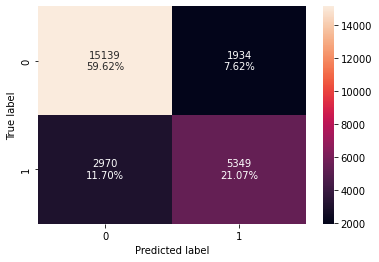

```python
# creating confusion matrix

confusion_matrix_statsmodels(lg1, X_train1.astype(float), y_train.astype(float))
```

```python
# code for the log_reg_model_train_perf

print("Training performance:")
log_reg_model_train_perf = model_performance_classification_statsmodels(
    lg1, X_train1.astype(float), y_train.astype(float)
)
log_reg_model_train_perf
```

```
Training performance:
```

|  | Accuracy | Recall | Precision | F1 |
| --- | --- | --- | --- | --- |
| 0 | 0.80687 | 0.64299 | 0.73445 | 0.68568 |

Observations: The training performance induces remain unchanged. SO the model is still performing at the same level.

### ROC-AUC

```
## ROC-AUC on training set
```

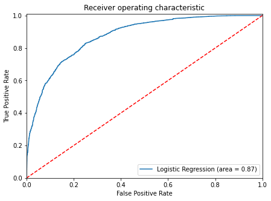

```python
logit_roc_auc_train = roc_auc_score(y_train, lg1.predict(X_train1))
fpr, tpr, thresholds = roc_curve(y_train, lg1.predict(X_train1))
plt.figure(figsize=(7, 5))
plt.plot(fpr, tpr, label="Logistic Regression (area = %0.2f)" % logit_roc_auc_train)
plt.plot([0, 1], [0, 1], "r--")
plt.xlim([0.0, 1.0])
plt.ylim([0.0, 1.01])
plt.xlabel("False Positive Rate")
plt.ylabel("True Positive Rate")
plt.title("Receiver operating characteristic")
plt.legend(loc="lower right")
plt.show()
```

#### Model Performance Improvement

##### Optimal threshold using AUC-ROC curve

```python
# Optimal threshold as per AUC-ROC curve
# The optimal cut off would be where tpr is high and fpr is low
fpr, tpr, thresholds = roc_curve(y_train, lg1.predict(X_train1))

optimal_idx = np.argmax(tpr - fpr)
optimal_threshold_auc_roc = thresholds[optimal_idx]
print(optimal_threshold_auc_roc)
```

```
0.28237048262101594
```

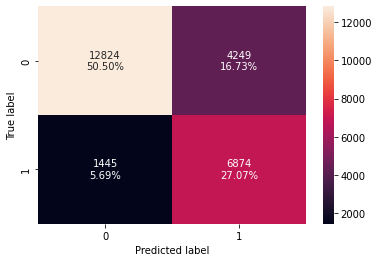

```python
# creating confusion matrix
## Code to create the confusion matrix for X_train1 and y_train with optimal_threshold_auc_roc as threshold

confusion_matrix_statsmodels(
    lg1, X_train1.astype(float), y_train.astype(float), threshold=optimal_threshold_auc_roc
)
```

```python
# checking model performance for this model
log_reg_model_train_perf_threshold_auc_roc = model_performance_classification_statsmodels(
    lg1, X_train1, y_train, threshold=optimal_threshold_auc_roc
)
print("Training performance:")
log_reg_model_train_perf_threshold_auc_roc
```

```
Training performance:
```

|  | Accuracy | Recall | Precision | F1 |
| --- | --- | --- | --- | --- |
| 0 | 0.77576 | 0.82630 | 0.61800 | 0.70713 |

#### Let's use Precision-Recall curve and see if we can find a better threshold

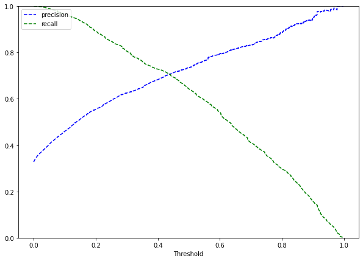

```python
y_scores = lg1.predict(X_train1)
prec, rec, tre = precision_recall_curve(y_train, y_scores,)


def plot_prec_recall_vs_tresh(precisions, recalls, thresholds):
    plt.plot(thresholds, precisions[:-1], "b--", label="precision")
    plt.plot(thresholds, recalls[:-1], "g--", label="recall")
    plt.xlabel("Threshold")
    plt.legend(loc="upper left")
    plt.ylim([0, 1])


plt.figure(figsize=(10, 7))
plot_prec_recall_vs_tresh(prec, rec, tre)
plt.show()
```

```python
# setting the threshold
optimal_threshold_curve = 0.42
```

##### Checking model performance on training set

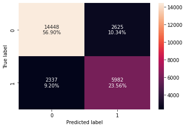

```python
# code to create the confusion matrix for X_train1 and y_train with optimal_threshold_curve as threshold
# creating confusion matrix

confusion_matrix_statsmodels(lg1, X_train1.astype(float), y_train.astype(float), threshold=optimal_threshold_curve)
```

```python
log_reg_model_train_perf_threshold_curve = model_performance_classification_statsmodels(
    lg1, X_train1, y_train, threshold=optimal_threshold_curve
)
print("Training performance:")
log_reg_model_train_perf_threshold_curve
```

```
Training performance:
```

|  | Accuracy | Recall | Precision | F1 |
| --- | --- | --- | --- | --- |
| 0 | 0.80458 | 0.71908 | 0.69502 | 0.70684 |

##### Let's check the performance on the test set

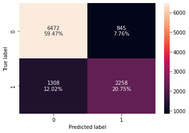

```python
# creating confusion matrix
confusion_matrix_statsmodels(lg1, X_test1, y_test)
```

```python
# code for the log_reg_model_train_perf

print("Testing performance:")
log_reg_model_test_perf = model_performance_classification_statsmodels(
    lg1, X_test1.astype(float), y_test.astype(float)
)
log_reg_model_test_perf
```

```
Testing performance:
```

|  | Accuracy | Recall | Precision | F1 |
| --- | --- | --- | --- | --- |
| 0 | 0.80217 | 0.63320 | 0.72768 | 0.67716 |

The Recall and F1 scores are not good so the model may not be efficient in prediction.

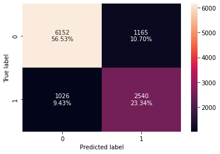

```python
#  ## Complete the code to create confusion matrix for X_test1 and y_test
# creating confusion matrix
confusion_matrix_statsmodels(lg1, X_test1.astype(float), y_test.astype(float), threshold=optimal_threshold_curve)
```

```python
# Code the code to check performance on X_test1 and y_test

log_reg_model_test_perf_threshold_curve = model_performance_classification_statsmodels(
    lg1, X_test1, y_test, threshold=optimal_threshold_curve
)
print("Testing performance:")
log_reg_model_test_perf_threshold_curve
```

```
Testing performance:
```

|  | Accuracy | Recall | Precision | F1 |
| --- | --- | --- | --- | --- |
| 0 | 0.79868 | 0.71228 | 0.68556 | 0.69867 |

Observations: The model has improved as bot the recall and F1 score have increase,

#### ROC curve on test set

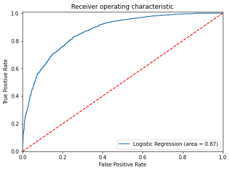

```python
logit_roc_auc_train = roc_auc_score(y_test, lg1.predict(X_test1))
fpr, tpr, thresholds = roc_curve(y_test, lg1.predict(X_test1))
plt.figure(figsize=(7, 5))
plt.plot(fpr, tpr, label="Logistic Regression (area = %0.2f)" % logit_roc_auc_train)
plt.plot([0, 1], [0, 1], "r--")
plt.xlim([0.0, 1.0])
plt.ylim([0.0, 1.01])
plt.xlabel("False Positive Rate")
plt.ylabel("True Positive Rate")
plt.title("Receiver operating characteristic")
plt.legend(loc="lower right")
plt.show()
```

Observations: ROC on the test data is 0.87 and there is not much change in recall and F1 score.

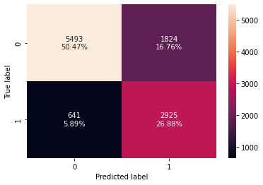

```python
# Code to create confusion matrix for X_test1 and y_test using optimal_threshold_auc_roc as threshold
# creating confusion matrix
confusion_matrix_statsmodels(lg1, X_test1.astype(float), y_test.astype(float), threshold=optimal_threshold_auc_roc)
```

```python
# checking model performance for this model
log_reg_model_test_perf_threshold_auc_roc = model_performance_classification_statsmodels(
    lg1, X_test1, y_test, threshold=optimal_threshold_auc_roc
)
print("Test performance:")
log_reg_model_test_perf_threshold_auc_roc
```

```
Test performance:
```

|  | Accuracy | Recall | Precision | F1 |
| --- | --- | --- | --- | --- |
| 0 | 0.77350 | 0.82025 | 0.61592 | 0.70355 |

The performance has improved and the model can make better prediction.

### Using model with threshold = 0.42

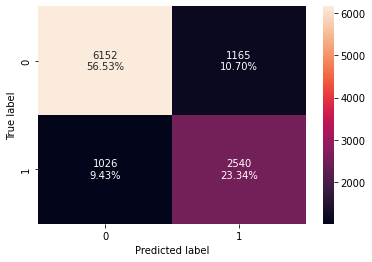

```python
# Complete the code to create confusion matrix for X_test1 and y_test using optimal_threshold_curve as threshold
# creating confusion matrix
confusion_matrix_statsmodels(lg1, X_test1.astype(float), y_test.astype(float), threshold=optimal_threshold_curve)
```

```python
# checking model performance for this model
log_reg_model_test_perf_threshold_curve = model_performance_classification_statsmodels(
    lg1, X_test1, y_test, threshold=optimal_threshold_curve
)
print("Test performance:")
log_reg_model_test_perf_threshold_curve
```

```
Test performance:
```

|  | Accuracy | Recall | Precision | F1 |
| --- | --- | --- | --- | --- |
| 0 | 0.79868 | 0.71228 | 0.68556 | 0.69867 |

Observations: The performance has gone down as both the recall and F1 score have reduced.

### Model performance summary

```python
# training performance comparison

models_train_comp_df = pd.concat(
    [
        log_reg_model_train_perf.T,
        log_reg_model_train_perf_threshold_auc_roc.T,
        log_reg_model_train_perf_threshold_curve.T,
    ],
    axis=1,
)
models_train_comp_df.columns = [
    "Logistic Regression-default Threshold",
    "Logistic Regression-0.37 Threshold",
    "Logistic Regression-0.42 Threshold",
]

print("Training performance comparison:")
models_train_comp_df
```

```
Training performance comparison:
```

|  | Logistic Regression-default Threshold | Logistic Regression-0.37 Threshold | Logistic Regression-0.42 Threshold |
| --- | --- | --- | --- |
| Accuracy | 0.80687 | 0.77576 | 0.80458 |
| Recall | 0.64299 | 0.82630 | 0.71908 |
| Precision | 0.73445 | 0.61800 | 0.69502 |
| F1 | 0.68568 | 0.70713 | 0.70684 |

```python
log_reg_model_test_perf_threshold_curve
```

|  | Accuracy | Recall | Precision | F1 |
| --- | --- | --- | --- | --- |
| 0 | 0.79868 | 0.71228 | 0.68556 | 0.69867 |

```python
# testing performance comparison

models_test_comp_df = pd.concat(
    [
        log_reg_model_test_perf.T,
        log_reg_model_test_perf_threshold_auc_roc.T,
        log_reg_model_test_perf_threshold_curve.T,
    ],
    axis=1,
)
models_test_comp_df.columns = [
    "Logistic Regression-default Threshold",
    "Logistic Regression-0.37 Threshold",
    "Logistic Regression-0.42 Threshold",
]

print("Testing performance comparison:")
models_test_comp_df
```

```
Testing performance comparison:
```

|  | Logistic Regression-default Threshold | Logistic Regression-0.37 Threshold | Logistic Regression-0.42 Threshold |
| --- | --- | --- | --- |
| Accuracy | 0.80217 | 0.77350 | 0.79868 |
| Recall | 0.63320 | 0.82025 | 0.71228 |
| Precision | 0.72768 | 0.61592 | 0.68556 |
| F1 | 0.67716 | 0.70355 | 0.69867 |

## Final Model Summary

From the logistic regression model we identified that various predictor variables such as no_of_week_nights, lead_time, arrival_year, type_of_meal_plan_Not Selected, room_type_reserved_Room_Type 7, market_segment_type_Offline, and others are significant predictors of potential booking cancellations.

Number_of_weekend_nights: This variable has a coefficient of 0.1576, indicating that an increase in the number of weekend nights positively influences the predicted log-odds of the event occurring.

Required_car_parking_space: This variable has a coefficient of -1.6112, suggesting that requiring car parking space negatively impacts the predicted log-odds of the event occurring.

Lead_time: With a coefficient of 0.0162, lead time positively affects the predicted log-odds of the event occurring.

Arrival_year: This variable has a coefficient of 0.4651, indicating a positive influence on the predicted log-odds of the event occurring.

Repeated_guest: Although not listed explicitly in the equation, if this variable is binary (indicating whether the guest is a repeated visitor), the coefficient of -3.1509 suggests that being a repeated guest negatively affects the predicted log-odds of the event occurring.

no_of_previous_cancellations: With a coefficient of 0.3843, this variable positively impacts the predicted log-odds of the event occurring.

avg_price_per_room: This variable has a coefficient of 0.0188, indicating a positive influence on the predicted log-odds of the event occurring.

no_of_special_requests: With a coefficient of -1.5475, an increase in the number of special requests negatively affects the predicted log-odds of the event occurring.

market_segment_type_Offline: This variable has a coefficient of -1.8257, suggesting that bookings made through offline market segments have a negative impact on the predicted log-odds of the event occurring.

In conclusion: The logistic regression equation reveals several key variables that significantly influence the predicted probability of the event occurring. These variables include:

Number_of_weekend_nights: More weekend nights booked tend to increase the likelihood of the event occurring. Required_car_parking_space: Requiring car parking space decreases the likelihood of the event occurring. Lead_time: Longer lead times positively impact the likelihood of the event occurring. Arrival_year: Bookings in later years positively influence the likelihood of the event occurring. Repeated_guest: Being a repeated guest negatively affects the likelihood of the event occurring. Number_of_previous_cancellations: Previous cancellations positively affect the likelihood of the event occurring. Average price_per_room: Higher average prices per room tend to increase the likelihood of the event occurring. Number_of_special_requests: More special requests decrease the likelihood of the event occurring.

Market_segment_type_Offline: Bookings made through offline market segments negatively impact the likelihood of the event occurring.

## Building a Decision Tree model

```python
# To filter the warnings
import warnings

warnings.filterwarnings("ignore")

# Libraries to help with reading and manipulating data
import pandas as pd
import numpy as np

# libaries to help with data visualization
import matplotlib.pyplot as plt
import seaborn as sns

# Removes the limit for the number of displayed columns
pd.set_option("display.max_columns", None)

# Sets the limit for the number of displayed rows
pd.set_option("display.max_rows", 200)

# setting the precision of floating numbers to 5 decimal points
pd.set_option("display.float_format", lambda x: "%.5f" % x)

# Library to split data
from sklearn.model_selection import train_test_split

# To build model for prediction
from sklearn.tree import DecisionTreeClassifier
from sklearn import tree

# To tune different models
from sklearn.model_selection import GridSearchCV

# To get diferent metric scores
from sklearn.metrics import (
    f1_score,
    accuracy_score,
    recall_score,
    precision_score,
    confusion_matrix,
    make_scorer,
)
```

```python
# copying data to another variable to avoid any changes to original data
data2 = hotel.copy()
```

```python
data2.shape
```

```
(36275, 19)
```

```python
data2.describe()
```

|  | no_of_adults | no_of_children | no_of_weekend_nights | no_of_week_nights | required_car_parking_space | lead_time | arrival_year | arrival_month | arrival_date | repeated_guest | no_of_previous_cancellations | no_of_previous_bookings_not_canceled | avg_price_per_room | no_of_special_requests |
| --- | --- | --- | --- | --- | --- | --- | --- | --- | --- | --- | --- | --- | --- | --- |
| count | 36275.00000 | 36275.00000 | 36275.00000 | 36275.00000 | 36275.00000 | 36275.00000 | 36275.00000 | 36275.00000 | 36275.00000 | 36275.00000 | 36275.00000 | 36275.00000 | 36275.00000 | 36275.00000 |
| mean | 1.84496 | 0.10528 | 0.81072 | 2.20430 | 0.03099 | 85.23256 | 2017.82043 | 7.42365 | 15.59700 | 0.02564 | 0.02335 | 0.15341 | 103.42354 | 0.61966 |
| std | 0.51871 | 0.40265 | 0.87064 | 1.41090 | 0.17328 | 85.93082 | 0.38384 | 3.06989 | 8.74045 | 0.15805 | 0.36833 | 1.75417 | 35.08942 | 0.78624 |
| min | 0.00000 | 0.00000 | 0.00000 | 0.00000 | 0.00000 | 0.00000 | 2017.00000 | 1.00000 | 1.00000 | 0.00000 | 0.00000 | 0.00000 | 0.00000 | 0.00000 |
| 25% | 2.00000 | 0.00000 | 0.00000 | 1.00000 | 0.00000 | 17.00000 | 2018.00000 | 5.00000 | 8.00000 | 0.00000 | 0.00000 | 0.00000 | 80.30000 | 0.00000 |
| 50% | 2.00000 | 0.00000 | 1.00000 | 2.00000 | 0.00000 | 57.00000 | 2018.00000 | 8.00000 | 16.00000 | 0.00000 | 0.00000 | 0.00000 | 99.45000 | 0.00000 |
| 75% | 2.00000 | 0.00000 | 2.00000 | 3.00000 | 0.00000 | 126.00000 | 2018.00000 | 10.00000 | 23.00000 | 0.00000 | 0.00000 | 0.00000 | 120.00000 | 1.00000 |
| max | 4.00000 | 10.00000 | 7.00000 | 17.00000 | 1.00000 | 443.00000 | 2018.00000 | 12.00000 | 31.00000 | 1.00000 | 13.00000 | 58.00000 | 540.00000 | 5.00000 |

```python
data2.info()
```

```
<class 'pandas.core.frame.DataFrame'>
RangeIndex: 36275 entries, 0 to 36274
Data columns (total 19 columns):
 #   Column                                Non-Null Count  Dtype
---  ------                                --------------  -----
 0   Booking_ID                            36275 non-null  object
 1   no_of_adults                          36275 non-null  int64
 2   no_of_children                        36275 non-null  int64
 3   no_of_weekend_nights                  36275 non-null  int64
 4   no_of_week_nights                     36275 non-null  int64
 5   type_of_meal_plan                     36275 non-null  object
 6   required_car_parking_space            36275 non-null  int64
 7   room_type_reserved                    36275 non-null  object
 8   lead_time                             36275 non-null  int64
 9   arrival_year                          36275 non-null  int64
 10  arrival_month                         36275 non-null  int64
 11  arrival_date                          36275 non-null  int64
 12  market_segment_type                   36275 non-null  object
 13  repeated_guest                        36275 non-null  int64
 14  no_of_previous_cancellations          36275 non-null  int64
 15  no_of_previous_bookings_not_canceled  36275 non-null  int64
 16  avg_price_per_room                    36275 non-null  float64
 17  no_of_special_requests                36275 non-null  int64
 18  booking_status                        36275 non-null  object
dtypes: float64(1), int64(13), object(5)
memory usage: 5.3+ MB
```

```python
data2 = data2.drop(["Booking_ID"], axis=1)
```

```python
data2.shape
```

```
(36275, 18)
```

```python
data2.head()
```

|  | no_of_adults | no_of_children | no_of_weekend_nights | no_of_week_nights | type_of_meal_plan | required_car_parking_space | room_type_reserved | lead_time | arrival_year | arrival_month | arrival_date | market_segment_type | repeated_guest | no_of_previous_cancellations | no_of_previous_bookings_not_canceled | avg_price_per_room | no_of_special_requests | booking_status |
| --- | --- | --- | --- | --- | --- | --- | --- | --- | --- | --- | --- | --- | --- | --- | --- | --- | --- | --- |
| 0 | 2 | 0 | 1 | 2 | Meal Plan 1 | 0 | Room_Type 1 | 224 | 2017 | 10 | 2 | Offline | 0 | 0 | 0 | 65.00000 | 0 | Not_Canceled |
| 1 | 2 | 0 | 2 | 3 | Not Selected | 0 | Room_Type 1 | 5 | 2018 | 11 | 6 | Online | 0 | 0 | 0 | 106.68000 | 1 | Not_Canceled |
| 2 | 1 | 0 | 2 | 1 | Meal Plan 1 | 0 | Room_Type 1 | 1 | 2018 | 2 | 28 | Online | 0 | 0 | 0 | 60.00000 | 0 | Canceled |
| 3 | 2 | 0 | 0 | 2 | Meal Plan 1 | 0 | Room_Type 1 | 211 | 2018 | 5 | 20 | Online | 0 | 0 | 0 | 100.00000 | 0 | Canceled |
| 4 | 2 | 0 | 1 | 1 | Not Selected | 0 | Room_Type 1 | 48 | 2018 | 4 | 11 | Online | 0 | 0 | 0 | 94.50000 | 0 | Canceled |

```python
data2.tail()
```

|  | no_of_adults | no_of_children | no_of_weekend_nights | no_of_week_nights | type_of_meal_plan | required_car_parking_space | room_type_reserved | lead_time | arrival_year | arrival_month | arrival_date | market_segment_type | repeated_guest | no_of_previous_cancellations | no_of_previous_bookings_not_canceled | avg_price_per_room | no_of_special_requests | booking_status |
| --- | --- | --- | --- | --- | --- | --- | --- | --- | --- | --- | --- | --- | --- | --- | --- | --- | --- | --- |
| 36270 | 3 | 0 | 2 | 6 | Meal Plan 1 | 0 | Room_Type 4 | 85 | 2018 | 8 | 3 | Online | 0 | 0 | 0 | 167.80000 | 1 | Not_Canceled |
| 36271 | 2 | 0 | 1 | 3 | Meal Plan 1 | 0 | Room_Type 1 | 228 | 2018 | 10 | 17 | Online | 0 | 0 | 0 | 90.95000 | 2 | Canceled |
| 36272 | 2 | 0 | 2 | 6 | Meal Plan 1 | 0 | Room_Type 1 | 148 | 2018 | 7 | 1 | Online | 0 | 0 | 0 | 98.39000 | 2 | Not_Canceled |
| 36273 | 2 | 0 | 0 | 3 | Not Selected | 0 | Room_Type 1 | 63 | 2018 | 4 | 21 | Online | 0 | 0 | 0 | 94.50000 | 0 | Canceled |
| 36274 | 2 | 0 | 1 | 2 | Meal Plan 1 | 0 | Room_Type 1 | 207 | 2018 | 12 | 30 | Offline | 0 | 0 | 0 | 161.67000 | 0 | Not_Canceled |

```python
data2.describe()
```

|  | no_of_adults | no_of_children | no_of_weekend_nights | no_of_week_nights | required_car_parking_space | lead_time | arrival_year | arrival_month | arrival_date | repeated_guest | no_of_previous_cancellations | no_of_previous_bookings_not_canceled | avg_price_per_room | no_of_special_requests |
| --- | --- | --- | --- | --- | --- | --- | --- | --- | --- | --- | --- | --- | --- | --- |
| count | 36275.00000 | 36275.00000 | 36275.00000 | 36275.00000 | 36275.00000 | 36275.00000 | 36275.00000 | 36275.00000 | 36275.00000 | 36275.00000 | 36275.00000 | 36275.00000 | 36275.00000 | 36275.00000 |
| mean | 1.84496 | 0.10528 | 0.81072 | 2.20430 | 0.03099 | 85.23256 | 2017.82043 | 7.42365 | 15.59700 | 0.02564 | 0.02335 | 0.15341 | 103.42354 | 0.61966 |
| std | 0.51871 | 0.40265 | 0.87064 | 1.41090 | 0.17328 | 85.93082 | 0.38384 | 3.06989 | 8.74045 | 0.15805 | 0.36833 | 1.75417 | 35.08942 | 0.78624 |
| min | 0.00000 | 0.00000 | 0.00000 | 0.00000 | 0.00000 | 0.00000 | 2017.00000 | 1.00000 | 1.00000 | 0.00000 | 0.00000 | 0.00000 | 0.00000 | 0.00000 |
| 25% | 2.00000 | 0.00000 | 0.00000 | 1.00000 | 0.00000 | 17.00000 | 2018.00000 | 5.00000 | 8.00000 | 0.00000 | 0.00000 | 0.00000 | 80.30000 | 0.00000 |
| 50% | 2.00000 | 0.00000 | 1.00000 | 2.00000 | 0.00000 | 57.00000 | 2018.00000 | 8.00000 | 16.00000 | 0.00000 | 0.00000 | 0.00000 | 99.45000 | 0.00000 |
| 75% | 2.00000 | 0.00000 | 2.00000 | 3.00000 | 0.00000 | 126.00000 | 2018.00000 | 10.00000 | 23.00000 | 0.00000 | 0.00000 | 0.00000 | 120.00000 | 1.00000 |
| max | 4.00000 | 10.00000 | 7.00000 | 17.00000 | 1.00000 | 443.00000 | 2018.00000 | 12.00000 | 31.00000 | 1.00000 | 13.00000 | 58.00000 | 540.00000 | 5.00000 |

```python
# encode Canceled bookings to 1 and Not_Canceled as 0 for further analysis
data2["booking_status"] = data2["booking_status"].apply(
    lambda x: 1 if x == "Canceled" else 0
)
```

```python
X = data2.drop(["booking_status"], axis=1)
Y = data2["booking_status"]

## Complete the code to create dummies for X

X = pd.get_dummies(X, drop_first=True)

# Splitting data in train and test sets
X_train, X_test, y_train, y_test = train_test_split(X, Y, test_size=0.30, random_state=1)
```

```python
print("Shape of Training set : ", X_train.shape)
print("Shape of test set : ", X_test.shape)
print("Percentage of classes in training set:")
print(y_train.value_counts(normalize=True))
print("Percentage of classes in test set:")
print(y_test.value_counts(normalize=True))
```

```
Shape of Training set :  (25392, 27)
Shape of test set :  (10883, 27)
Percentage of classes in training set:
0   0.67064
1   0.32936
Name: booking_status, dtype: float64
Percentage of classes in test set:
0   0.67638
1   0.32362
Name: booking_status, dtype: float64
```

We create functions to calculate different metrics and confusion matrix so that we don't have to use the same code repeatedly for each model. The model_performance_classification_sklearn function will be used to check the model performance of models. The confusion_matrix_sklearnfunction will be used to plot the confusion matrix.

```python
# defining a function to compute different metrics to check performance of a classification model built using sklearn
def model_performance_classification_sklearn(model, predictors, target):
    """
    Function to compute different metrics to check classification model performance

    model: classifier
    predictors: independent variables
    target: dependent variable
    """

    # predicting using the independent variables
    pred = model.predict(predictors)

    acc = accuracy_score(target, pred)  # to compute Accuracy
    recall = recall_score(target, pred)  # to compute Recall
    precision = precision_score(target, pred)  # to compute Precision
    f1 = f1_score(target, pred)  # to compute F1-score

    # creating a dataframe of metrics
    df_perf = pd.DataFrame(
        {"Accuracy": acc, "Recall": recall, "Precision": precision, "F1": f1,},
        index=[0],
    )

    return df_perf
```

```python
def confusion_matrix_sklearn(model, predictors, target):
    """
    To plot the confusion_matrix with percentages

    model: classifier
    predictors: independent variables
    target: dependent variable
    """
    y_pred = model.predict(predictors)
    cm = confusion_matrix(target, y_pred)
    labels = np.asarray(
        [
            ["{0:0.0f}".format(item) + "\n{0:.2%}".format(item / cm.flatten().sum())]
            for item in cm.flatten()
        ]
    ).reshape(2, 2)

    plt.figure(figsize=(6, 4))
    sns.heatmap(cm, annot=labels, fmt="")
    plt.ylabel("True label")
    plt.xlabel("Predicted label")
```

Building Decision Tree Model¶

```python
 ## Complete the code to fit decision tree on train data

model = DecisionTreeClassifier(random_state=1)
model.fit(X_train, y_train)
```

```
DecisionTreeClassifier(random_state=1)
```

Checking model performance on training set

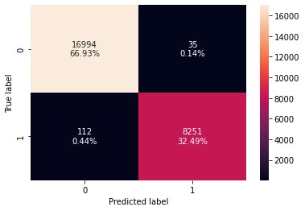

```python
# Complete the code to create confusion matrix for train data
confusion_matrix_sklearn(model,X_train,y_train)
```

```python
decision_tree_perf_train = model_performance_classification_sklearn(
    model, X_train, y_train
)
decision_tree_perf_train
```

|  | Accuracy | Recall | Precision | F1 |
| --- | --- | --- | --- | --- |
| 0 | 0.99421 | 0.98661 | 0.99578 | 0.99117 |

### Checking model performance on test set

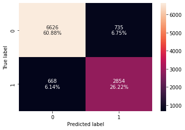

```python
## Complete the code to create confusion matrix for test data
confusion_matrix_sklearn(model, X_test, y_test)
```

```python
decision_tree_perf_test = model_performance_classification_sklearn(
    model, X_test, y_test
)
decision_tree_perf_test
```

|  | Accuracy | Recall | Precision | F1 |
| --- | --- | --- | --- | --- |
| 0 | 0.87108 | 0.81034 | 0.79521 | 0.80270 |

The Recall and F1 scores on the test data are lower compared to training dataset.

Before pruning the tree let's check the important features.

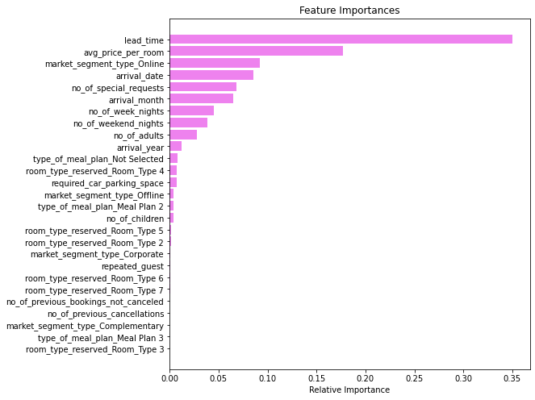

```python
feature_names = list(X_train.columns)
importances = model.feature_importances_
indices = np.argsort(importances)

plt.figure(figsize=(8, 8))
plt.title("Feature Importances")
plt.barh(range(len(indices)), importances[indices], color="violet", align="center")
plt.yticks(range(len(indices)), [feature_names[i] for i in indices])
plt.xlabel("Relative Importance")
plt.show()
```